# Risk Factor Analysis

## Outcome Variable

**Outcome Variable:** whz

## Predictor Variables

**Intervention Variable:** nchldlt5

**Adjustment Set:**

- arm
- W_mage
- meducyrs
- feducyrs
- hhwealth_quart
- hfoodsec
- W_mhtcm
- W_nrooms
- W_parity
- impfloor
- impsan
- safeh20
- delta_W_mage
- delta_meducyrs
- delta_feducyrs
- delta_hhwealth_quart
- delta_hfoodsec
- delta_W_mhtcm
- delta_W_nrooms
- delta_W_parity
- delta_impfloor
- delta_impsan
- delta_safeh20

## Stratifying Variables

The analysis was stratified on these variable(s):

- agecat
- studyid
- country

## Data Summary

| agecat | studyid | country | nchldlt5 | n_cell | n |
| --- | --- | --- | --- | --- | --- |
| Birth | ki1000108-IRC | INDIA | 1 | 72 | 245 |
| Birth | ki1000108-IRC | INDIA | 2+ | 173 | 245 |
| Birth | ki1017093c-NIH-Crypto | BANGLADESH | 1 | 15 | 16 |
| Birth | ki1017093c-NIH-Crypto | BANGLADESH | 2+ | 1 | 16 |
| Birth | kiGH5241-JiVitA-3 | BANGLADESH | 1 | 9384 | 9772 |
| Birth | kiGH5241-JiVitA-3 | BANGLADESH | 2+ | 388 | 9772 |
| 6 months | ki1000108-IRC | INDIA | 1 | 88 | 289 |
| 6 months | ki1000108-IRC | INDIA | 2+ | 201 | 289 |
| 6 months | ki1017093b-PROVIDE | BANGLADESH | 1 | 426 | 435 |
| 6 months | ki1017093b-PROVIDE | BANGLADESH | 2+ | 9 | 435 |
| 6 months | ki1017093c-NIH-Crypto | BANGLADESH | 1 | 507 | 512 |
| 6 months | ki1017093c-NIH-Crypto | BANGLADESH | 2+ | 5 | 512 |
| 6 months | ki1066203-TanzaniaChild2 | TANZANIA, UNITED REPUBLIC OF | 1 | 1390 | 1452 |
| 6 months | ki1066203-TanzaniaChild2 | TANZANIA, UNITED REPUBLIC OF | 2+ | 62 | 1452 |
| 6 months | ki1148112-LCNI-5 | MALAWI | 1 | 390 | 453 |
| 6 months | ki1148112-LCNI-5 | MALAWI | 2+ | 63 | 453 |
| 6 months | kiGH5241-JiVitA-3 | BANGLADESH | 1 | 10872 | 11234 |
| 6 months | kiGH5241-JiVitA-3 | BANGLADESH | 2+ | 362 | 11234 |
| 24 months | ki1000108-IRC | INDIA | 1 | 89 | 290 |
| 24 months | ki1000108-IRC | INDIA | 2+ | 201 | 290 |
| 24 months | ki1017093b-PROVIDE | BANGLADESH | 1 | 423 | 431 |
| 24 months | ki1017093b-PROVIDE | BANGLADESH | 2+ | 8 | 431 |
| 24 months | ki1017093c-NIH-Crypto | BANGLADESH | 1 | 357 | 361 |
| 24 months | ki1017093c-NIH-Crypto | BANGLADESH | 2+ | 4 | 361 |
| 24 months | ki1066203-TanzaniaChild2 | TANZANIA, UNITED REPUBLIC OF | 1 | 5 | 5 |
| 24 months | ki1066203-TanzaniaChild2 | TANZANIA, UNITED REPUBLIC OF | 2+ | 0 | 5 |
| 24 months | ki1148112-LCNI-5 | MALAWI | 1 | 277 | 321 |
| 24 months | ki1148112-LCNI-5 | MALAWI | 2+ | 44 | 321 |
| 24 months | kiGH5241-JiVitA-3 | BANGLADESH | 1 | 5434 | 5654 |
| 24 months | kiGH5241-JiVitA-3 | BANGLADESH | 2+ | 220 | 5654 |

The following strata were considered:

- agecat: 24 months, studyid: ki1000108-IRC, country: INDIA
- agecat: 24 months, studyid: ki1017093b-PROVIDE, country: BANGLADESH
- agecat: 24 months, studyid: ki1017093c-NIH-Crypto, country: BANGLADESH
- agecat: 24 months, studyid: ki1066203-TanzaniaChild2, country: TANZANIA, UNITED REPUBLIC OF
- agecat: 24 months, studyid: ki1148112-LCNI-5, country: MALAWI
- agecat: 24 months, studyid: kiGH5241-JiVitA-3, country: BANGLADESH
- agecat: 6 months, studyid: ki1000108-IRC, country: INDIA
- agecat: 6 months, studyid: ki1017093b-PROVIDE, country: BANGLADESH
- agecat: 6 months, studyid: ki1017093c-NIH-Crypto, country: BANGLADESH
- agecat: 6 months, studyid: ki1066203-TanzaniaChild2, country: TANZANIA, UNITED REPUBLIC OF
- agecat: 6 months, studyid: ki1148112-LCNI-5, country: MALAWI
- agecat: 6 months, studyid: kiGH5241-JiVitA-3, country: BANGLADESH
- agecat: Birth, studyid: ki1000108-IRC, country: INDIA
- agecat: Birth, studyid: ki1017093c-NIH-Crypto, country: BANGLADESH
- agecat: Birth, studyid: kiGH5241-JiVitA-3, country: BANGLADESH

### Dropped Strata

Some strata were dropped due to rare outcomes:

- agecat: Birth, studyid: ki1017093c-NIH-Crypto, country: BANGLADESH
- agecat: 24 months, studyid: ki1017093c-NIH-Crypto, country: BANGLADESH
- agecat: 24 months, studyid: ki1066203-TanzaniaChild2, country: TANZANIA, UNITED REPUBLIC OF

## Methods Detail

We’re interested in the causal parameters $E[Y_a]$ for all values of $a \in \mathcal{A}$. These parameters represent the mean outcome if, possibly contrary to fact, we intervened to set all units to have $A=a$. Under the randomization and positivity assumptions, these are identified by the statistical parameters $\psi_a=E_W[E_{Y|A,W}(Y|A=a,W)]$. In addition, we’re interested in the mean of $Y$, $E[Y]$ under no intervention (the observed mean). We will estimate these parameters by using SuperLearner to fit the relevant likelihood factors – $E_{Y|A,W}(Y|A=a,W)$ and $p(A=a|W)$, and then updating our likelihood fit using a joint TMLE.

For unadjusted analyses ($W=\{\}$), initial likelihoods were estimated using Lrnr_glm to estimate the simple $E(Y|A)$ and Lrnr_mean to estimate $p(A)$. For adjusted analyses, a small library containing Lrnr_glmnet, Lrnr_xgboost, and Lrnr_mean was used.

Having estimated these parameters, we will then use the delta method to estimate relative risks and attributable risks relative to a prespecified baseline level of $A$.

# Results Detail

## Results Plots

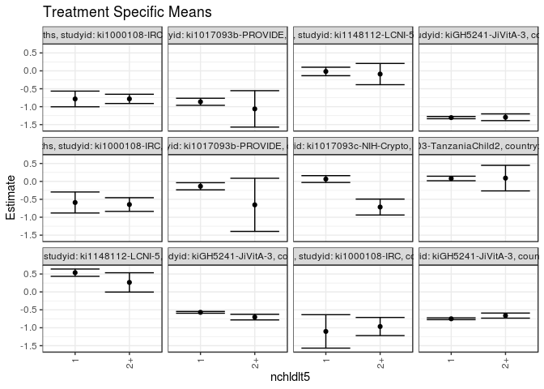

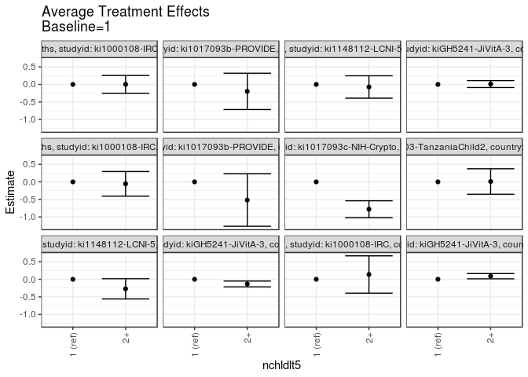

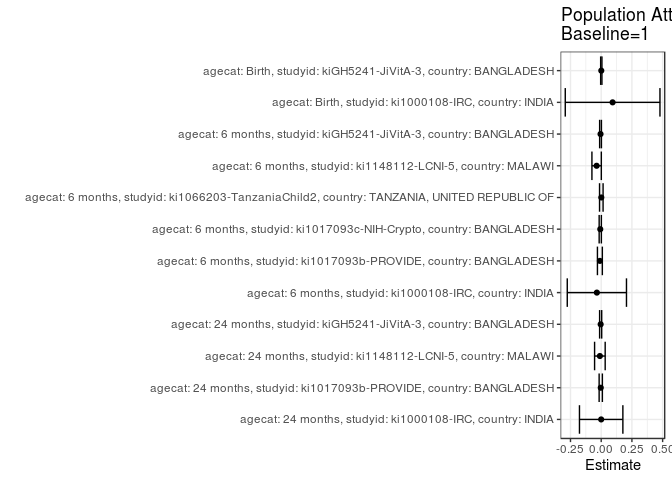

## Results Table

### Parameter: TSM

| agecat | studyid | country | intervention_level | baseline_level | estimate | ci_lower | ci_upper |
| --- | --- | --- | --- | --- | --- | --- | --- |
| Birth | ki1000108-IRC | INDIA | 1 | NA | -1.1023244 | -1.5688266 | -0.6358222 |
| Birth | ki1000108-IRC | INDIA | 2+ | NA | -0.9653735 | -1.2186562 | -0.7120908 |
| Birth | kiGH5241-JiVitA-3 | BANGLADESH | 1 | NA | -0.7495004 | -0.7745468 | -0.7244539 |
| Birth | kiGH5241-JiVitA-3 | BANGLADESH | 2+ | NA | -0.6608902 | -0.7316419 | -0.5901385 |
| 6 months | ki1000108-IRC | INDIA | 1 | NA | -0.5890870 | -0.8827708 | -0.2954032 |
| 6 months | ki1000108-IRC | INDIA | 2+ | NA | -0.6458165 | -0.8368177 | -0.4548152 |
| 6 months | ki1017093b-PROVIDE | BANGLADESH | 1 | NA | -0.1362715 | -0.2362441 | -0.0362990 |
| 6 months | ki1017093b-PROVIDE | BANGLADESH | 2+ | NA | -0.6544444 | -1.3959478 | 0.0870589 |
| 6 months | ki1017093c-NIH-Crypto | BANGLADESH | 1 | NA | 0.0648718 | -0.0302953 | 0.1600388 |
| 6 months | ki1017093c-NIH-Crypto | BANGLADESH | 2+ | NA | -0.7160000 | -0.9380762 | -0.4939238 |
| 6 months | ki1066203-TanzaniaChild2 | TANZANIA, UNITED REPUBLIC OF | 1 | NA | 0.0808423 | 0.0174154 | 0.1442691 |
| 6 months | ki1066203-TanzaniaChild2 | TANZANIA, UNITED REPUBLIC OF | 2+ | NA | 0.0912315 | -0.2657337 | 0.4481967 |
| 6 months | ki1148112-LCNI-5 | MALAWI | 1 | NA | 0.5369375 | 0.4351075 | 0.6387675 |
| 6 months | ki1148112-LCNI-5 | MALAWI | 2+ | NA | 0.2652061 | -0.0043023 | 0.5347145 |
| 6 months | kiGH5241-JiVitA-3 | BANGLADESH | 1 | NA | -0.5699545 | -0.5951282 | -0.5447808 |
| 6 months | kiGH5241-JiVitA-3 | BANGLADESH | 2+ | NA | -0.7029931 | -0.7819285 | -0.6240577 |
| 24 months | ki1000108-IRC | INDIA | 1 | NA | -0.7838758 | -1.0021691 | -0.5655824 |
| 24 months | ki1000108-IRC | INDIA | 2+ | NA | -0.7817642 | -0.9102339 | -0.6532944 |
| 24 months | ki1017093b-PROVIDE | BANGLADESH | 1 | NA | -0.8634043 | -0.9623023 | -0.7645062 |
| 24 months | ki1017093b-PROVIDE | BANGLADESH | 2+ | NA | -1.0612500 | -1.5690182 | -0.5534818 |
| 24 months | ki1148112-LCNI-5 | MALAWI | 1 | NA | -0.0167864 | -0.1352447 | 0.1016720 |
| 24 months | ki1148112-LCNI-5 | MALAWI | 2+ | NA | -0.0899496 | -0.3860196 | 0.2061204 |
| 24 months | kiGH5241-JiVitA-3 | BANGLADESH | 1 | NA | -1.3047234 | -1.3359435 | -1.2735034 |
| 24 months | kiGH5241-JiVitA-3 | BANGLADESH | 2+ | NA | -1.2945447 | -1.3881095 | -1.2009799 |

### Parameter: E(Y)

| agecat | studyid | country | intervention_level | baseline_level | estimate | ci_lower | ci_upper |
| --- | --- | --- | --- | --- | --- | --- | --- |
| Birth | ki1000108-IRC | INDIA | NA | NA | -1.0094286 | -1.2311616 | -0.7876956 |
| Birth | kiGH5241-JiVitA-3 | BANGLADESH | NA | NA | -0.7487659 | -0.7726563 | -0.7248754 |
| 6 months | ki1000108-IRC | INDIA | NA | NA | -0.6243253 | -0.7833786 | -0.4652719 |
| 6 months | ki1017093b-PROVIDE | BANGLADESH | NA | NA | -0.1469923 | -0.2464550 | -0.0475297 |
| 6 months | ki1017093c-NIH-Crypto | BANGLADESH | NA | NA | 0.0572461 | -0.0359459 | 0.1504381 |
| 6 months | ki1066203-TanzaniaChild2 | TANZANIA, UNITED REPUBLIC OF | NA | NA | 0.0817637 | 0.0194495 | 0.1440778 |
| 6 months | ki1148112-LCNI-5 | MALAWI | NA | NA | 0.4996468 | 0.4052394 | 0.5940542 |
| 6 months | kiGH5241-JiVitA-3 | BANGLADESH | NA | NA | -0.5754055 | -0.5983356 | -0.5524753 |
| 24 months | ki1000108-IRC | INDIA | NA | NA | -0.7841264 | -0.8946395 | -0.6736134 |
| 24 months | ki1017093b-PROVIDE | BANGLADESH | NA | NA | -0.8670766 | -0.9643669 | -0.7697862 |
| 24 months | ki1148112-LCNI-5 | MALAWI | NA | NA | -0.0275234 | -0.1369083 | 0.0818616 |
| 24 months | kiGH5241-JiVitA-3 | BANGLADESH | NA | NA | -1.3091670 | -1.3388782 | -1.2794557 |

### Parameter: ATE

| agecat | studyid | country | intervention_level | baseline_level | estimate | ci_lower | ci_upper |
| --- | --- | --- | --- | --- | --- | --- | --- |
| Birth | ki1000108-IRC | INDIA | 1 | 1 | 0.0000000 | 0.0000000 | 0.0000000 |
| Birth | ki1000108-IRC | INDIA | 2+ | 1 | 0.1369509 | -0.3945866 | 0.6684884 |
| Birth | kiGH5241-JiVitA-3 | BANGLADESH | 1 | 1 | 0.0000000 | 0.0000000 | 0.0000000 |
| Birth | kiGH5241-JiVitA-3 | BANGLADESH | 2+ | 1 | 0.0886101 | 0.0136312 | 0.1635891 |
| 6 months | ki1000108-IRC | INDIA | 1 | 1 | 0.0000000 | 0.0000000 | 0.0000000 |
| 6 months | ki1000108-IRC | INDIA | 2+ | 1 | -0.0567294 | -0.4076640 | 0.2942051 |
| 6 months | ki1017093b-PROVIDE | BANGLADESH | 1 | 1 | 0.0000000 | 0.0000000 | 0.0000000 |
| 6 months | ki1017093b-PROVIDE | BANGLADESH | 2+ | 1 | -0.5181729 | -1.2663853 | 0.2300394 |
| 6 months | ki1017093c-NIH-Crypto | BANGLADESH | 1 | 1 | 0.0000000 | 0.0000000 | 0.0000000 |
| 6 months | ki1017093c-NIH-Crypto | BANGLADESH | 2+ | 1 | -0.7808718 | -1.0224801 | -0.5392634 |
| 6 months | ki1066203-TanzaniaChild2 | TANZANIA, UNITED REPUBLIC OF | 1 | 1 | 0.0000000 | 0.0000000 | 0.0000000 |
| 6 months | ki1066203-TanzaniaChild2 | TANZANIA, UNITED REPUBLIC OF | 2+ | 1 | 0.0103892 | -0.3526004 | 0.3733789 |
| 6 months | ki1148112-LCNI-5 | MALAWI | 1 | 1 | 0.0000000 | 0.0000000 | 0.0000000 |
| 6 months | ki1148112-LCNI-5 | MALAWI | 2+ | 1 | -0.2717314 | -0.5603615 | 0.0168986 |
| 6 months | kiGH5241-JiVitA-3 | BANGLADESH | 1 | 1 | 0.0000000 | 0.0000000 | 0.0000000 |
| 6 months | kiGH5241-JiVitA-3 | BANGLADESH | 2+ | 1 | -0.1330387 | -0.2161862 | -0.0498911 |
| 24 months | ki1000108-IRC | INDIA | 1 | 1 | 0.0000000 | 0.0000000 | 0.0000000 |
| 24 months | ki1000108-IRC | INDIA | 2+ | 1 | 0.0021116 | -0.2516149 | 0.2558381 |
| 24 months | ki1017093b-PROVIDE | BANGLADESH | 1 | 1 | 0.0000000 | 0.0000000 | 0.0000000 |
| 24 months | ki1017093b-PROVIDE | BANGLADESH | 2+ | 1 | -0.1978457 | -0.7151555 | 0.3194640 |
| 24 months | ki1148112-LCNI-5 | MALAWI | 1 | 1 | 0.0000000 | 0.0000000 | 0.0000000 |
| 24 months | ki1148112-LCNI-5 | MALAWI | 2+ | 1 | -0.0731632 | -0.3919744 | 0.2456479 |
| 24 months | kiGH5241-JiVitA-3 | BANGLADESH | 1 | 1 | 0.0000000 | 0.0000000 | 0.0000000 |
| 24 months | kiGH5241-JiVitA-3 | BANGLADESH | 2+ | 1 | 0.0101787 | -0.0885653 | 0.1089227 |

### Parameter: PAR

| agecat | studyid | country | intervention_level | baseline_level | estimate | ci_lower | ci_upper |
| --- | --- | --- | --- | --- | --- | --- | --- |
| Birth | ki1000108-IRC | INDIA | 1 | NA | 0.0928958 | -0.2924851 | 0.4782767 |
| Birth | kiGH5241-JiVitA-3 | BANGLADESH | 1 | NA | 0.0007345 | -0.0044160 | 0.0058850 |
| 6 months | ki1000108-IRC | INDIA | 1 | NA | -0.0352382 | -0.2762250 | 0.2057485 |
| 6 months | ki1017093b-PROVIDE | BANGLADESH | 1 | NA | -0.0107208 | -0.0306718 | 0.0092302 |
| 6 months | ki1017093c-NIH-Crypto | BANGLADESH | 1 | NA | -0.0076257 | -0.0166152 | 0.0013638 |
| 6 months | ki1066203-TanzaniaChild2 | TANZANIA, UNITED REPUBLIC OF | 1 | NA | 0.0009214 | -0.0134315 | 0.0152743 |
| 6 months | ki1148112-LCNI-5 | MALAWI | 1 | NA | -0.0372907 | -0.0755458 | 0.0009644 |
| 6 months | kiGH5241-JiVitA-3 | BANGLADESH | 1 | NA | -0.0054510 | -0.0126822 | 0.0017802 |
| 24 months | ki1000108-IRC | INDIA | 1 | NA | -0.0002507 | -0.1768876 | 0.1763863 |
| 24 months | ki1017093b-PROVIDE | BANGLADESH | 1 | NA | -0.0036723 | -0.0168490 | 0.0095044 |
| 24 months | ki1148112-LCNI-5 | MALAWI | 1 | NA | -0.0107370 | -0.0538615 | 0.0323875 |
| 24 months | kiGH5241-JiVitA-3 | BANGLADESH | 1 | NA | -0.0044435 | -0.0129116 | 0.0040246 |